# Nigeria Markets and Flows - FEWS NET 2008

# Introduction

An analysis of markets and flows of food products helps to determine both the demand for crop products as well an indication the current sources of crops for specific markets or regions.

The market flows can be used in conjunction with the sub national biofortification indices (e.g. Herrington et al. 2018) to show if intervention and impact zones are being connected by existing market flows.

The flow maps are a useful graphical tool to help support the marketing networks for biofortified crops, and to identify any gaps in the marketing system that might be undermining the market for biofortified products. The market flow maps can identify which physical markets could be a surveyed for information on demand for biofortified crops, and/or for interventions which seek to promote biofortified crops.

In 2008 FEWS NET obtained information on major markets for five crops to map the flows of harvested products within Nigeria, noting states which had a surplus of production (often the source) and those that had a deficit of production.

Maps were produced for five crops:

1. Cassava (FEWS NET 2008a)
2. Cowpea (FEWS NET 2008b)
3. Maize (FEWS NET 2008c)
4. Millet (FEWS NET 2008d)
5. Sorghum (FEWS NET 2008e)

## Markets in Nigeria

The markets across the five crops were consistent, but the type or function of the market sometimes changed, according to the crop.

Three types of markets were identified:

- Assembly market - where smaller quantities of a commodity are accumulated or aggregated usually from different farmers and small scale traders. Assembly markets facilitate marketing and the movement of commodities as well as reduce the costs of marketing. They can also enable sellers of smaller surpluses from more remote locations to reach distant buyers (FEWS NET 2009).
- Retail market - where commodities are largely sold to end users, especially consumers. Per transaction volumes tend to be smaller, for example per kg or small bowl (FEWS NET 2009).
- Wholesale - where generally traders sell to traders. Per transaction volumes tend to be larger, e.g., multiple 50 kg bags and even metric tons (FEWS NET 2009)
- Unknown - Some of the maps do not give information on the market function or type

There are also some locations that combine functions:

- Retail and Wholesale
- Assembly and Wholesale
- Assembly, Retail and Wholesale

## Market flows in Nigeria

The flows indicate movement of crop products from areas of production that tend to have a surplus, to those areas where there is a no production but demand, or areas where there is insufficient production to meet the demand.

The original FEWS NET maps show major flows and minor flows, but do not indicate the actual volumes of the flows.

# Methods

The market locations were identified in GoogleEarth and saved as a csv file.

The market flows were constructed using a Bezier curve with 2, 3, or 4 control points, to replicate as closely as possible the flows in the original FEWS NET market flow maps.

# Data Preparation

## Load the market points

```r
df_markets_geo <- read.csv("tab_data/markets nigeria.csv")
vect_markets_geo <- vect(df_markets_geo)
vect_markets_labels_geo <- vect(df_markets_geo, geom = c("Label_long",  "Label_lat"))
crs(vect_markets_labels_geo) <- "epsg:4326"

vect_markets_geo$Name_2 <- as.factor(vect_markets_geo$Name_2)

cat(paste("Market Names: ", levels(vect_markets_geo$Name_2), "; ")) # Check levels
```

```
Market Names:  Aba ;  Market Names:  Aliero ;  Market Names:  Bakori ;  Market Names:  Bama ;  Market Names:  Buni Yadi ;  Market Names:  Damasak ;  Market Names:  Dan Dume ;  Market Names:  Danja ;  Market Names:  Dawanau ;  Market Names:  Dodoru ;  Market Names:  Enugu ;  Market Names:  Funtua ;  …
```

## Load the states

```r
vect_state_geo <- vect("D:/DatosProyecto/SpatialData/Africa/Pais/Nigeria/NGA Admin 2019-2025 OSGOF-Ehealth-UNCS/nga_admin1_topo.topojson")

crs(vect_state_geo) <- "epsg:4326"

vect_state_geo$adm1_pcode <- as.factor(vect_state_geo$adm1_pcode)

cat(paste("State Codes: ",levels(vect_state_geo$adm1_pcode), "; ")) # Check levels
```

```
State Codes:  NG001 ;  State Codes:  NG002 ;  State Codes:  NG003 ;  State Codes:  NG004 ;  State Codes:  NG005 ;  State Codes:  NG006 ;  State Codes:  NG007 ;  State Codes:  NG008 ;  State Codes:  NG009 ;  State Codes:  NG010 ;  State Codes:  NG011 ;  State Codes:  NG012 ;  State Codes:  NG013 ;  S…
```

## Plot the market points

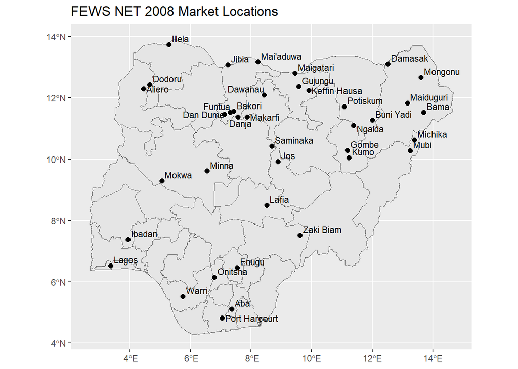

Figure 1: FEWS NET 2008 Market Locations

```r
ggplot(vect_state_geo) +
  geom_spatvector() +
  geom_spatvector(data = vect_markets_geo, size = 2) +
  geom_spatvector_text(
    data = vect_markets_labels_geo,
    aes(
      label = Name_2,
      hjust = case_when(
        Name_2 == "Danja" ~ 0.5,
        Name_2 == "Dawanau" ~ 1,
        Name_2 == "Dan Dume" ~ 1,
        Name_2 == "Funtua" ~ 1,
        TRUE                 ~ 0   # Default fallback (left)
      )
    ),
    size = 3,
    check_overlap = F
  ) +
  labs(title = "FEWS NET 2008 Market Locations") +
  theme(
    plot.title = element_markdown(),
    axis.title = element_blank()
  )
```

## Load and create the market flows

### Cassava market flows

```r
# Read CSV

df_cassava_flow_points <- read.csv("tab_data/market_flows_cassava.csv")


# Create point SpatVector in EPSG:4326

vect_cassava_flow_points <- terra::vect(
  df_cassava_flow_points,
  geom = c("long", "lat"),
  crs = "EPSG:4326"
)


# Project points for curve calculation

curve_crs <- "EPSG:32632"

vect_cassava_flow_points_projected <- terra::project(
  vect_cassava_flow_points,
  curve_crs
)

df_flow_cassava <- as.data.frame(
  vect_cassava_flow_points_projected,
  geom = "XY"
)


# df_flow_cassava |>
#   arrange(flow_id, sequence)


# Generate curves

df_smooth_flows_cassava <- df_flow_cassava |>

  arrange(flow_id, sequence) |>

  group_by(flow_id, flow) |>

  group_modify(
    ~ {
      make_bezier(
        x = .x$x,
        y = .x$y,
        n = 100
      )
    }
  ) |>

  ungroup()


# check smooth_flows

ggplot() +
  geom_path(
    data = df_smooth_flows_cassava,
    aes(
      x = x,
      y = y,
      group = flow_id,
      linewidth = flow
    ), colour = "darkgrey"
  ) +
  scale_linewidth(
    range = c(0.5, 1)
  ) +
  geom_spatvector_label(
    data = vect_cassava_flow_points_projected,
    aes(label = paste(flow_id,"-", sequence)),
    size = 2
  )


#create a list where each element corresponds explicitly to a flow_id

flow_ids <- unique(df_smooth_flows_cassava$flow_id)

geometries <- lapply(
  flow_ids,
  function(id) {
    d <- df_smooth_flows_cassava |>
      filter(flow_id == id)

    cbind(
      d$x,
      d$y
    )
  }
)


#create the attribute table using the same flow_ids order

df_flow_attributes_cassava <- df_smooth_flows_cassava |>
  distinct(flow_id, flow) |>
  arrange(match(flow_id, flow_ids))


# Check that the orders match

flow_ids
```

```
 [1]  1  2  3  4  5  6  7  8  9 10 11 12 13 14 15 16 17
```

```r
df_flow_attributes_cassava$flow_id
```

```
 [1]  1  2  3  4  5  6  7  8  9 10 11 12 13 14 15 16 17
```

```r
# Create the SpatVector

vect_smooth_flows_cassava <- terra::vect(
  geometries,
  type = "lines",
  crs = curve_crs
)


# attach the attributes

values(vect_smooth_flows_cassava) <- df_flow_attributes_cassava


# check

vect_smooth_flows_cassava
```

```
class       : SpatVector
geometry    : lines
dimensions  : 17, 2  (geometries, attributes)
extent      : -210976.3, 1105625, 546555.8, 1546772  (xmin, xmax, ymin, ymax)
coord. ref. : WGS 84 / UTM zone 32N (EPSG:32632)
names       : flow_id  flow
type        :   <int> <int>
values      :       1     2
                    2     2
                    3     2
              ...
```

```r
plot(vect_smooth_flows_cassava)


# Transform back to EPSG:4326

vect_smooth_flows_cassava <- terra::project(
  vect_smooth_flows_cassava,
  "EPSG:4326"
)

crs(vect_smooth_flows_cassava)
```

```
[1] "GEOGCRS[\"WGS 84\",\n    ENSEMBLE[\"World Geodetic System 1984 ensemble\",\n        MEMBER[\"World Geodetic System 1984 (Transit)\"],\n        MEMBER[\"World Geodetic System 1984 (G730)\"],\n        MEMBER[\"World Geodetic System 1984 (G873)\"],\n        MEMBER[\"World Geodetic System 1984 (G11…
```

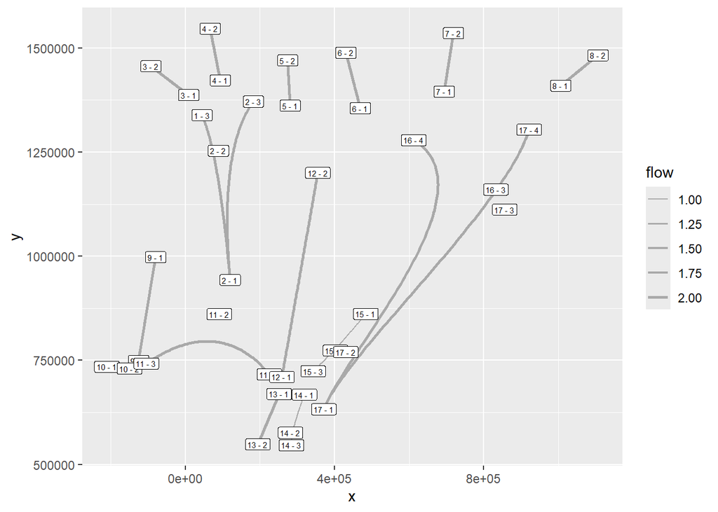

(a) Control points and smooth flows

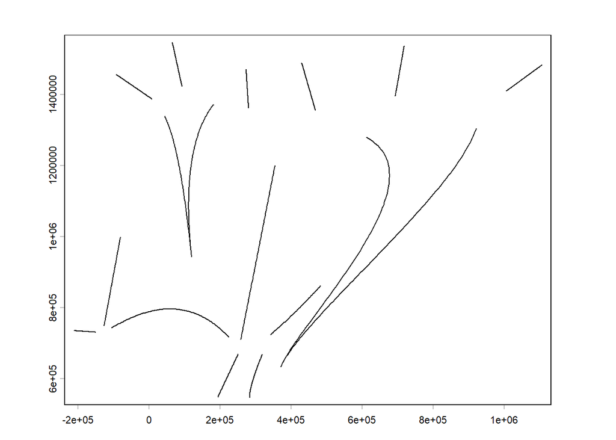

(b) Final flows

Figure 2: Cassava Market Flows

### Cowpea market flows

```r
# Read CSV

df_cowpea_flow_points <- read.csv("tab_data/market_flows_cowpea.csv")


# Create point SpatVector in EPSG:4326

vect_cowpea_flow_points <- terra::vect(
  df_cowpea_flow_points,
  geom = c("long", "lat"),
  crs = "EPSG:4326"
)


# Project points for curve calculation

curve_crs <- "EPSG:32632"

vect_cowpea_flow_points_projected <- terra::project(
  vect_cowpea_flow_points,
  curve_crs
)

df_flow_cowpea <- as.data.frame(
  vect_cowpea_flow_points_projected,
  geom = "XY"
)


# df_flow_cowpea |>
#   arrange(flow_id, sequence)


# Generate curves

df_smooth_flows_cowpea <- df_flow_cowpea |>

  arrange(flow_id, sequence) |>

  group_by(flow_id, flow) |>

  group_modify(
    ~ {
      make_bezier(
        x = .x$x,
        y = .x$y,
        n = 100
      )
    }
  ) |>

  ungroup()


# check smooth_flows

ggplot() +
  geom_path(
    data = df_smooth_flows_cowpea,
    aes(
      x = x,
      y = y,
      group = flow_id,
      linewidth = flow
    ), colour = "darkgrey"
  ) +
  scale_linewidth(
    range = c(0.5, 1)
  ) +
  geom_spatvector_label(
    data = vect_cowpea_flow_points_projected,
    aes(label = paste(flow_id,"-", sequence)),
    size = 2
  )


#create a list where each element corresponds explicitly to a flow_id

flow_ids <- unique(df_smooth_flows_cowpea$flow_id)

geometries <- lapply(
  flow_ids,
  function(id) {
    d <- df_smooth_flows_cowpea |>
      filter(flow_id == id)

    cbind(
      d$x,
      d$y
    )
  }
)


#create the attribute table using the same flow_ids order

df_flow_attributes_cowpea <- df_smooth_flows_cowpea |>
  distinct(flow_id, flow) |>
  arrange(match(flow_id, flow_ids))


# Check that the orders match

flow_ids
```

```
 [1]  1  2  3  4  5  6  7  8  9 10 11 12 13 14 16 17 18 19 20
```

```r
df_flow_attributes_cowpea$flow_id
```

```
 [1]  1  2  3  4  5  6  7  8  9 10 11 12 13 14 16 17 18 19 20
```

```r
# Create the SpatVector

vect_smooth_flows_cowpea <- terra::vect(
  geometries,
  type = "lines",
  crs = curve_crs
)


# attach the attributes

values(vect_smooth_flows_cowpea) <- df_flow_attributes_cowpea


# check

vect_smooth_flows_cowpea
```

```
class       : SpatVector
geometry    : lines
dimensions  : 19, 2  (geometries, attributes)
extent      : -126006.4, 1105625, 580572.9, 1546772  (xmin, xmax, ymin, ymax)
coord. ref. : WGS 84 / UTM zone 32N (EPSG:32632)
names       : flow_id  flow
type        :   <int> <int>
values      :       1     1
                    2     1
                    3     2
              ...
```

```r
plot(vect_smooth_flows_cowpea)


# Transform back to EPSG:4326

vect_smooth_flows_cowpea <- terra::project(
  vect_smooth_flows_cowpea,
  "EPSG:4326"
)

crs(vect_smooth_flows_cowpea)
```

```
[1] "GEOGCRS[\"WGS 84\",\n    ENSEMBLE[\"World Geodetic System 1984 ensemble\",\n        MEMBER[\"World Geodetic System 1984 (Transit)\"],\n        MEMBER[\"World Geodetic System 1984 (G730)\"],\n        MEMBER[\"World Geodetic System 1984 (G873)\"],\n        MEMBER[\"World Geodetic System 1984 (G11…
```

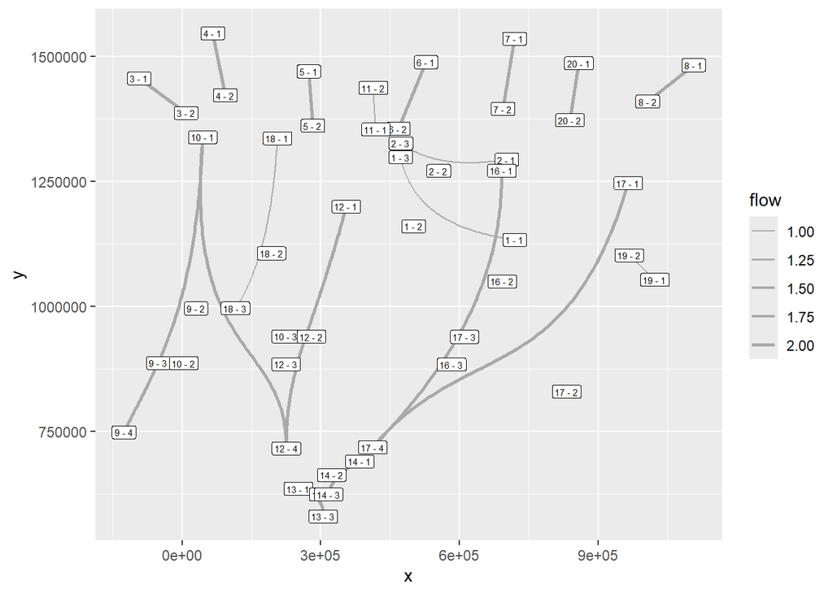

(a) Control points and smooth flows

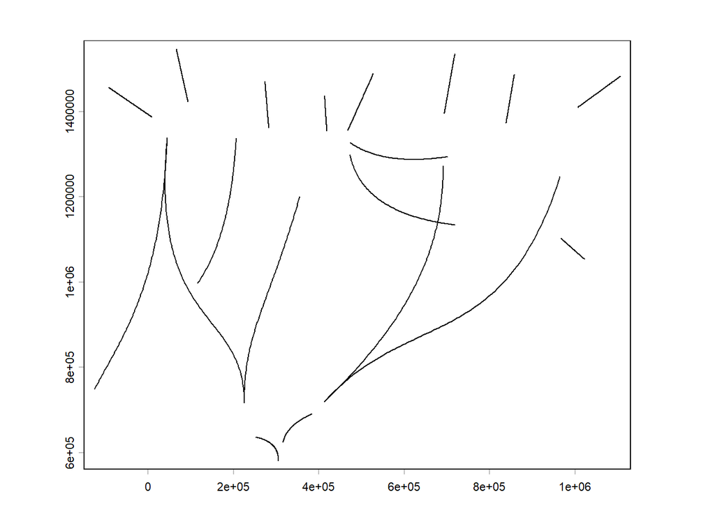

(b) Final flows

Figure 3: Cowpea Market Flows

### Maize market flows

```r
# Read CSV

df_maize_flow_points <- read.csv("tab_data/market_flows_maize.csv")


# Create point SpatVector in EPSG:4326

vect_maize_flow_points <- terra::vect(
  df_maize_flow_points,
  geom = c("long", "lat"),
  crs = "EPSG:4326"
)


# Project points for curve calculation

curve_crs <- "EPSG:32632"

vect_maize_flow_points_projected <- terra::project(
  vect_maize_flow_points,
  curve_crs
)

df_flow_maize <- as.data.frame(
  vect_maize_flow_points_projected,
  geom = "XY"
)


# df_flow_maize |>
#   arrange(flow_id, sequence)


# Generate curves

df_smooth_flows_maize <- df_flow_maize |>

  arrange(flow_id, sequence) |>

  group_by(flow_id, flow) |>

  group_modify(
    ~ {
      make_bezier(
        x = .x$x,
        y = .x$y,
        n = 100
      )
    }
  ) |>

  ungroup()


# check smooth_flows

ggplot() +
  geom_path(
    data = df_smooth_flows_maize,
    aes(
      x = x,
      y = y,
      group = flow_id,
      linewidth = flow
    ), colour = "darkgrey"
  ) +
  scale_linewidth(
    range = c(0.5, 1)
  ) +
  geom_spatvector_label(
    data = vect_maize_flow_points_projected,
    aes(label = paste(flow_id,"-", sequence)),
    size = 2
  )


#create a list where each element corresponds explicitly to a flow_id

flow_ids <- unique(df_smooth_flows_maize$flow_id)

geometries <- lapply(
  flow_ids,
  function(id) {
    d <- df_smooth_flows_maize |>
      filter(flow_id == id)

    cbind(
      d$x,
      d$y
    )
  }
)


#create the attribute table using the same flow_ids order

df_flow_attributes_maize <- df_smooth_flows_maize |>
  distinct(flow_id, flow) |>
  arrange(match(flow_id, flow_ids))


# Check that the orders match

flow_ids
```

```
 [1]  1  2  3  4  5  6  7  8  9 10 11 12 13 14 15 16 17 18 19 20 21 22 23
```

```r
df_flow_attributes_maize$flow_id
```

```
 [1]  1  2  3  4  5  6  7  8  9 10 11 12 13 14 15 16 17 18 19 20 21 22 23
```

```r
# Create the SpatVector

vect_smooth_flows_maize <- terra::vect(
  geometries,
  type = "lines",
  crs = curve_crs
)


# attach the attributes

values(vect_smooth_flows_maize) <- df_flow_attributes_maize


# check

vect_smooth_flows_maize
```

```
class       : SpatVector
geometry    : lines
dimensions  : 23, 2  (geometries, attributes)
extent      : -265792.6, 1100648, 644225.4, 1529532  (xmin, xmax, ymin, ymax)
coord. ref. : WGS 84 / UTM zone 32N (EPSG:32632)
names       : flow_id  flow
type        :   <int> <int>
values      :       1     2
                    2     2
                    3     2
              ...
```

```r
plot(vect_smooth_flows_maize)


# Transform back to EPSG:4326

vect_smooth_flows_maize <- terra::project(
  vect_smooth_flows_maize,
  "EPSG:4326"
)

crs(vect_smooth_flows_maize)
```

```
[1] "GEOGCRS[\"WGS 84\",\n    ENSEMBLE[\"World Geodetic System 1984 ensemble\",\n        MEMBER[\"World Geodetic System 1984 (Transit)\"],\n        MEMBER[\"World Geodetic System 1984 (G730)\"],\n        MEMBER[\"World Geodetic System 1984 (G873)\"],\n        MEMBER[\"World Geodetic System 1984 (G11…
```

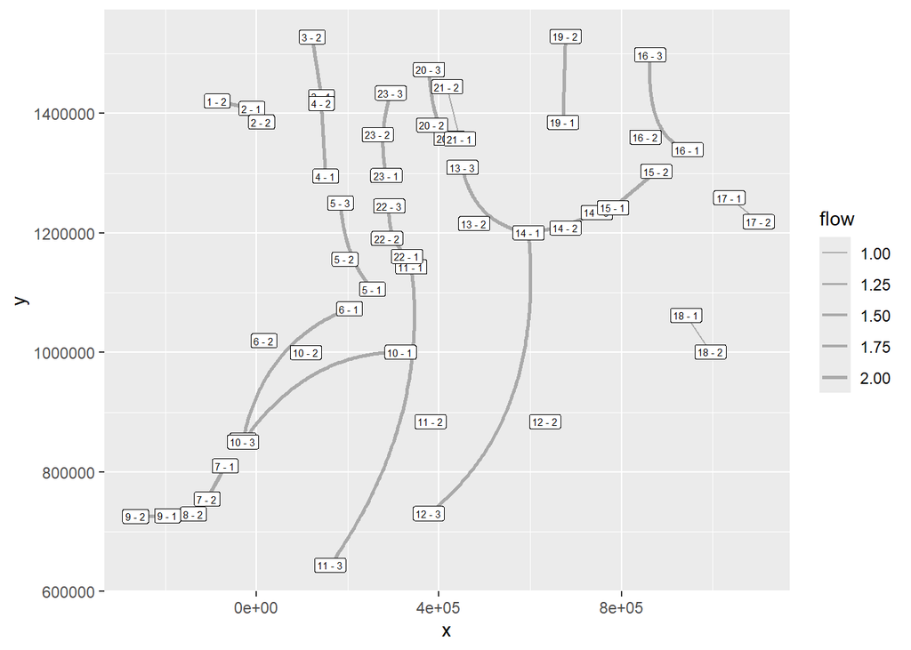

(a) Control points and smooth flows

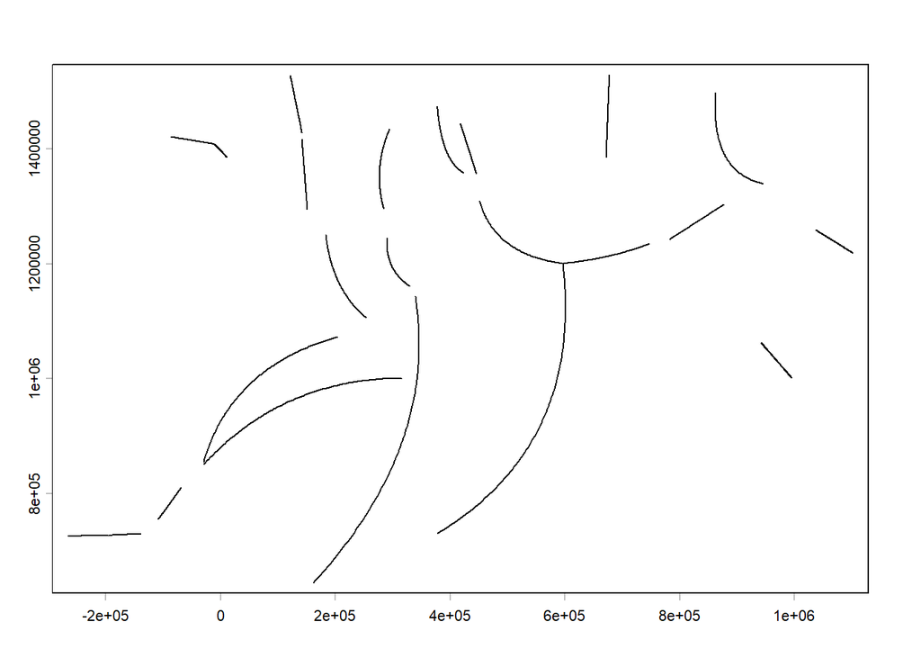

(b) Final flows

Figure 4: Maize Market Flows

### Millet market flows

```r
# Read CSV

df_millet_flow_points <- read.csv("tab_data/market_flows_millet.csv")


# Create point SpatVector in EPSG:4326

vect_millet_flow_points <- terra::vect(
  df_millet_flow_points,
  geom = c("long", "lat"),
  crs = "EPSG:4326"
)


# Project points for curve calculation

curve_crs <- "EPSG:32632"

vect_millet_flow_points_projected <- terra::project(
  vect_millet_flow_points,
  curve_crs
)

df_flow_millet <- as.data.frame(
  vect_millet_flow_points_projected,
  geom = "XY"
)


# df_flow_millet |>
#   arrange(flow_id, sequence)


# Generate curves

df_smooth_flows_millet <- df_flow_millet |>

  arrange(flow_id, sequence) |>

  group_by(flow_id, flow) |>

  group_modify(
    ~ {
      make_bezier(
        x = .x$x,
        y = .x$y,
        n = 100
      )
    }
  ) |>

  ungroup()


# check smooth_flows

ggplot() +
  geom_path(
    data = df_smooth_flows_millet,
    aes(
      x = x,
      y = y,
      group = flow_id,
      linewidth = flow
    ), colour = "darkgrey"
  ) +
  scale_linewidth(
    range = c(0.5, 1)
  ) +
  geom_spatvector_label(
    data = vect_millet_flow_points_projected,
    aes(label = paste(flow_id,"-", sequence)),
    size = 2
  )


#create a list where each element corresponds explicitly to a flow_id

flow_ids <- unique(df_smooth_flows_millet$flow_id)

geometries <- lapply(
  flow_ids,
  function(id) {
    d <- df_smooth_flows_millet |>
      filter(flow_id == id)

    cbind(
      d$x,
      d$y
    )
  }
)


#create the attribute table using the same flow_ids order

df_flow_attributes_millet <- df_smooth_flows_millet |>
  distinct(flow_id, flow) |>
  arrange(match(flow_id, flow_ids))


# Check that the orders match

flow_ids
```

```
 [1]  1  2  3  4  5  6  7  8  9 10 11 12 13 14 15 16 17
```

```r
df_flow_attributes_millet$flow_id
```

```
 [1]  1  2  3  4  5  6  7  8  9 10 11 12 13 14 15 16 17
```

```r
# Create the SpatVector

vect_smooth_flows_millet <- terra::vect(
  geometries,
  type = "lines",
  crs = curve_crs
)


# attach the attributes

values(vect_smooth_flows_millet) <- df_flow_attributes_millet


# check

vect_smooth_flows_millet
```

```
class       : SpatVector
geometry    : lines
dimensions  : 17, 2  (geometries, attributes)
extent      : -68089.93, 1180367, 627900.4, 1538259  (xmin, xmax, ymin, ymax)
coord. ref. : WGS 84 / UTM zone 32N (EPSG:32632)
names       : flow_id  flow
type        :   <int> <int>
values      :       1     2
                    2     1
                    3     2
              ...
```

```r
plot(vect_smooth_flows_millet)


# Transform back to EPSG:4326

vect_smooth_flows_millet <- terra::project(
  vect_smooth_flows_millet,
  "EPSG:4326"
)

crs(vect_smooth_flows_millet)
```

```
[1] "GEOGCRS[\"WGS 84\",\n    ENSEMBLE[\"World Geodetic System 1984 ensemble\",\n        MEMBER[\"World Geodetic System 1984 (Transit)\"],\n        MEMBER[\"World Geodetic System 1984 (G730)\"],\n        MEMBER[\"World Geodetic System 1984 (G873)\"],\n        MEMBER[\"World Geodetic System 1984 (G11…
```

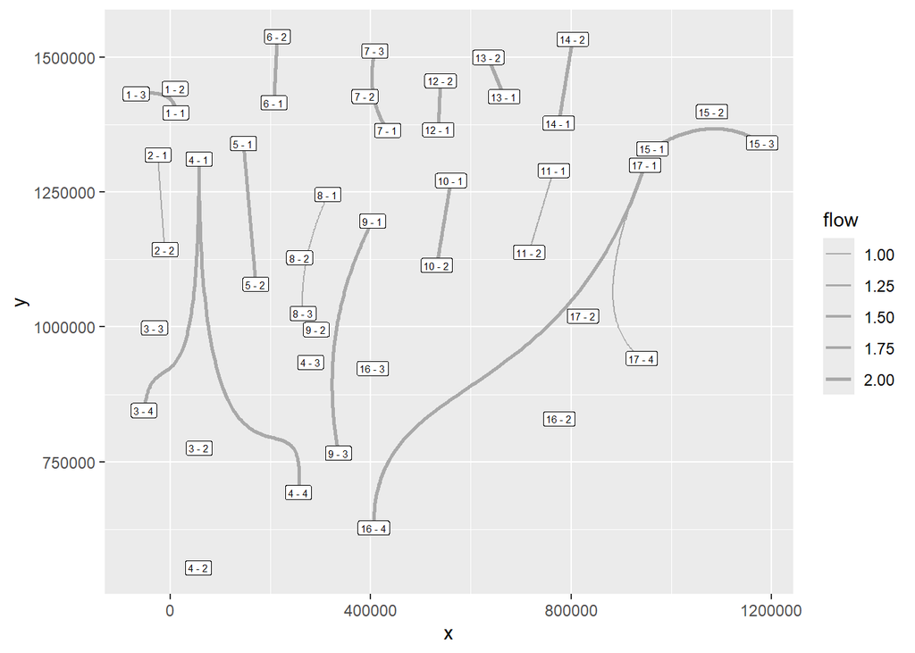

(a) Control points and smooth flows

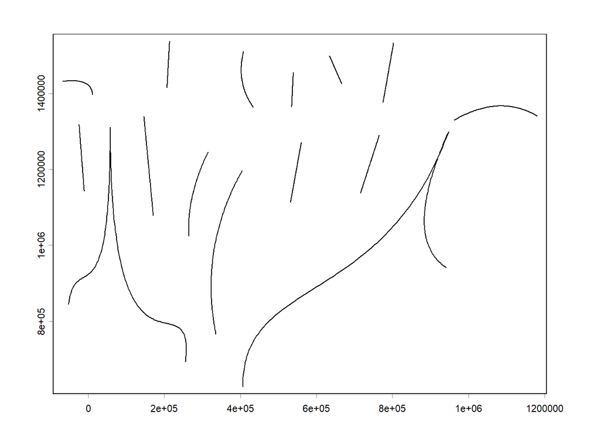

(b) Final flows

Figure 5: Millet Market Flows

### Sorghum market flows

```r
# Read CSV

df_sorghum_flow_points <- read.csv("tab_data/market_flows_sorghum.csv")


# Create point SpatVector in EPSG:4326

vect_sorghum_flow_points <- terra::vect(
  df_sorghum_flow_points,
  geom = c("long", "lat"),
  crs = "EPSG:4326"
)


# Project points for curve calculation

curve_crs <- "EPSG:32632"

vect_sorghum_flow_points_projected <- terra::project(
  vect_sorghum_flow_points,
  curve_crs
)

df_flow_sorghum <- as.data.frame(
  vect_sorghum_flow_points_projected,
  geom = "XY"
)


# df_flow_sorghum |>
#   arrange(flow_id, sequence)


# Generate curves

df_smooth_flows_sorghum <- df_flow_sorghum |>

  arrange(flow_id, sequence) |>

  group_by(flow_id, flow) |>

  group_modify(
    ~ {
      make_bezier(
        x = .x$x,
        y = .x$y,
        n = 100
      )
    }
  ) |>

  ungroup()


# check smooth_flows

ggplot() +
  geom_path(
    data = df_smooth_flows_sorghum,
    aes(
      x = x,
      y = y,
      group = flow_id,
      linewidth = flow
    ), colour = "darkgrey"
  ) +
  scale_linewidth(
    range = c(0.5, 1)
  ) +
  geom_spatvector_label(
    data = vect_sorghum_flow_points_projected,
    aes(label = paste(flow_id,"-", sequence)),
    size = 2
  )


#create a list where each element corresponds explicitly to a flow_id

flow_ids <- unique(df_smooth_flows_sorghum$flow_id)

geometries <- lapply(
  flow_ids,
  function(id) {
    d <- df_smooth_flows_sorghum |>
      filter(flow_id == id)

    cbind(
      d$x,
      d$y
    )
  }
)


#create the attribute table using the same flow_ids order

df_flow_attributes_sorghum <- df_smooth_flows_sorghum |>
  distinct(flow_id, flow) |>
  arrange(match(flow_id, flow_ids))


# Check that the orders match

flow_ids
```

```
 [1]  1  2  3  4  5  6  7  8  9 10 11 12 13 14 15 16 17
```

```r
df_flow_attributes_sorghum$flow_id
```

```
 [1]  1  2  3  4  5  6  7  8  9 10 11 12 13 14 15 16 17
```

```r
# Create the SpatVector

vect_smooth_flows_sorghum <- terra::vect(
  geometries,
  type = "lines",
  crs = curve_crs
)


# attach the attributes

values(vect_smooth_flows_sorghum) <- df_flow_attributes_sorghum


# check

vect_smooth_flows_sorghum
```

```
class       : SpatVector
geometry    : lines
dimensions  : 17, 2  (geometries, attributes)
extent      : -68089.93, 1180367, 558525.2, 1538259  (xmin, xmax, ymin, ymax)
coord. ref. : WGS 84 / UTM zone 32N (EPSG:32632)
names       : flow_id  flow
type        :   <int> <int>
values      :       1     2
                    2     1
                    3     2
              ...
```

```r
plot(vect_smooth_flows_sorghum)


# Transform back to EPSG:4326

vect_smooth_flows_sorghum <- terra::project(
  vect_smooth_flows_sorghum,
  "EPSG:4326"
)

crs(vect_smooth_flows_sorghum)
```

```
[1] "GEOGCRS[\"WGS 84\",\n    ENSEMBLE[\"World Geodetic System 1984 ensemble\",\n        MEMBER[\"World Geodetic System 1984 (Transit)\"],\n        MEMBER[\"World Geodetic System 1984 (G730)\"],\n        MEMBER[\"World Geodetic System 1984 (G873)\"],\n        MEMBER[\"World Geodetic System 1984 (G11…
```

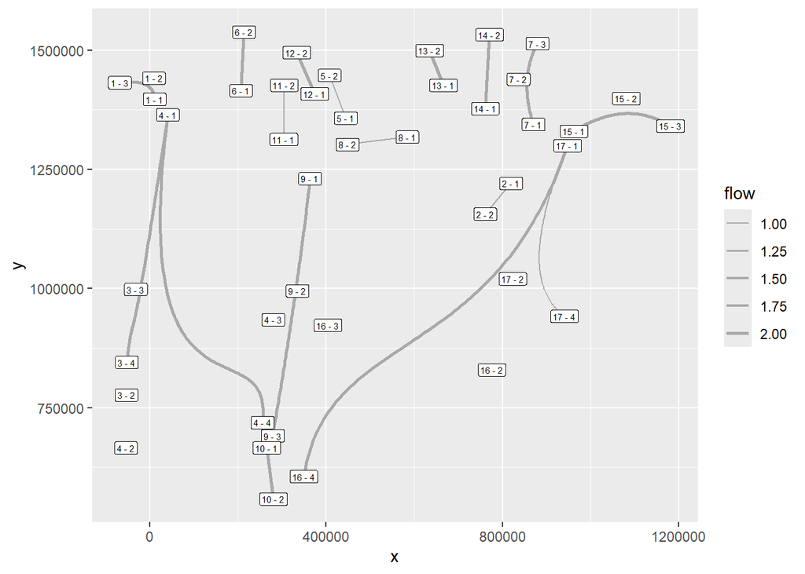

(a) Control points and smooth flows

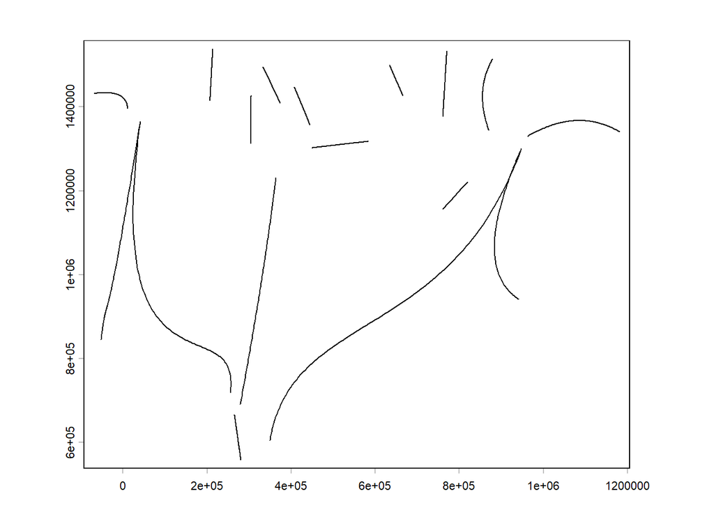

(b) Final flows

Figure 6: Sorghum Market Flows

# Cassava Markets

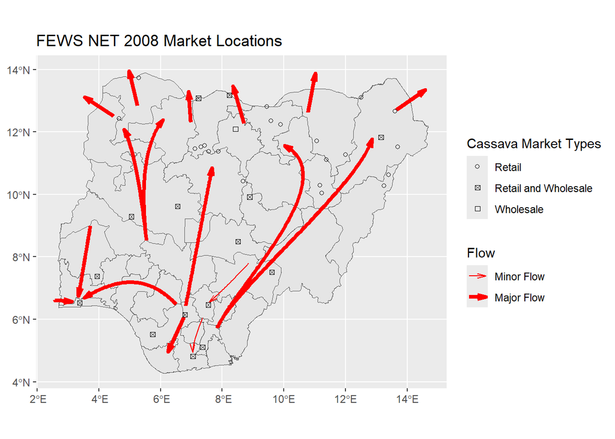

Figure 7: FEWS NET 2008 Cassava Markets

```r
Cassava = c("A", "A_R_W", "A_W", "R", "R_W", "W", "?")
m_shape  = c(2, 11, 15, 1, 7, 0, 63)
m_label  = c("Assembly", "Assembly, Retail and Wholesale", "Assembly and Wholesale", "Retail", "Retail and Wholesale", "Wholesale", "Unknown")


df_markets_shapes <- data.frame(Cassava = Cassava, m_shape = m_shape, m_label = m_label)

vect_markets_shapes <- tidyterra::left_join(vect_markets_geo, df_markets_shapes, by = c("Cassava") )

vect_smooth_flows_cassava$flow <- factor(vect_smooth_flows_cassava$flow, labels = c("Minor Flow", "Major Flow"))

linewidth_map <- c(
  "Minor Flow" = 0.5,
  "Major Flow" = 1.5 )

ggplot(vect_state_geo) +
  geom_spatvector() +
  geom_spatvector(
    data = vect_smooth_flows_cassava, aes(linewidth = factor(flow)),
    colour = "red",
    arrow = arrow(angle = 15, length = unit(0.25, "cm"),type = "open")
  ) +
  scale_linewidth_manual(
    name = "Flow",  # Legend title
    values = linewidth_map  # Map factor levels to linewidths
  ) +
  geom_spatvector(
    data = vect_markets_shapes,
    aes(shape = Cassava)
  ) +
  scale_shape_manual(
    values = setNames(
      df_markets_shapes$m_shape,
      df_markets_shapes$Cassava)
    ,
    breaks = df_markets_shapes$Cassava,
    labels = df_markets_shapes$m_label
  ) +
  labs(title = "FEWS NET 2008 Market Locations", shape = "Cassava Market Types") +
  theme(
    plot.title = element_markdown(),
    axis.title = element_blank()
  )
```

# Cowpea Markets

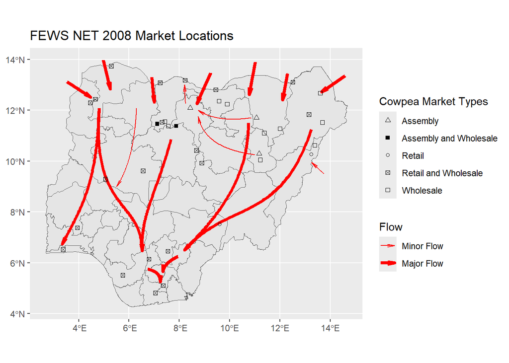

Figure 8: FEWS NET 2008 Cowpea Markets

```r
Cowpea = c("A", "A_R_W", "A_W", "R", "R_W", "W", "?")
m_shape  = c(2, 11, 15, 1, 7, 0, 63)
m_label  = c("Assembly", "Assembly, Retail and Wholesale", "Assembly and Wholesale", "Retail", "Retail and Wholesale", "Wholesale", "Unknown")


df_markets_shapes <- data.frame(Cowpea = Cowpea, m_shape = m_shape, m_label = m_label)

vect_markets_shapes <- tidyterra::left_join(vect_markets_geo, df_markets_shapes, by = c("Cowpea") )

vect_smooth_flows_cowpea$flow <- factor(vect_smooth_flows_cowpea$flow, labels = c("Minor Flow", "Major Flow"))

linewidth_map <- c(
  "Minor Flow" = 0.5,
  "Major Flow" = 1.5 )

ggplot(vect_state_geo) +
  geom_spatvector() +
    geom_spatvector(
    data = vect_smooth_flows_cowpea, aes(linewidth = flow),
    colour = "red",
    arrow = arrow(angle = 10, length = unit(0.25, "cm"),type = "open")
  ) +
  scale_linewidth_manual(
    name = "Flow",  # Legend title
    values = linewidth_map  # Map factor levels to linewidths
  ) +
  geom_spatvector(
    data = vect_markets_shapes,
    aes(shape = Cowpea)
  ) +
  scale_shape_manual(
    values = setNames(
      df_markets_shapes$m_shape,
      df_markets_shapes$Cowpea)
    ,
    breaks = df_markets_shapes$Cowpea,
    labels = df_markets_shapes$m_label
  ) +
  labs(title = "FEWS NET 2008 Market Locations", shape = "Cowpea Market Types") +
  theme(
    plot.title = element_markdown(),
    axis.title = element_blank()
  )
```

# Maize Markets

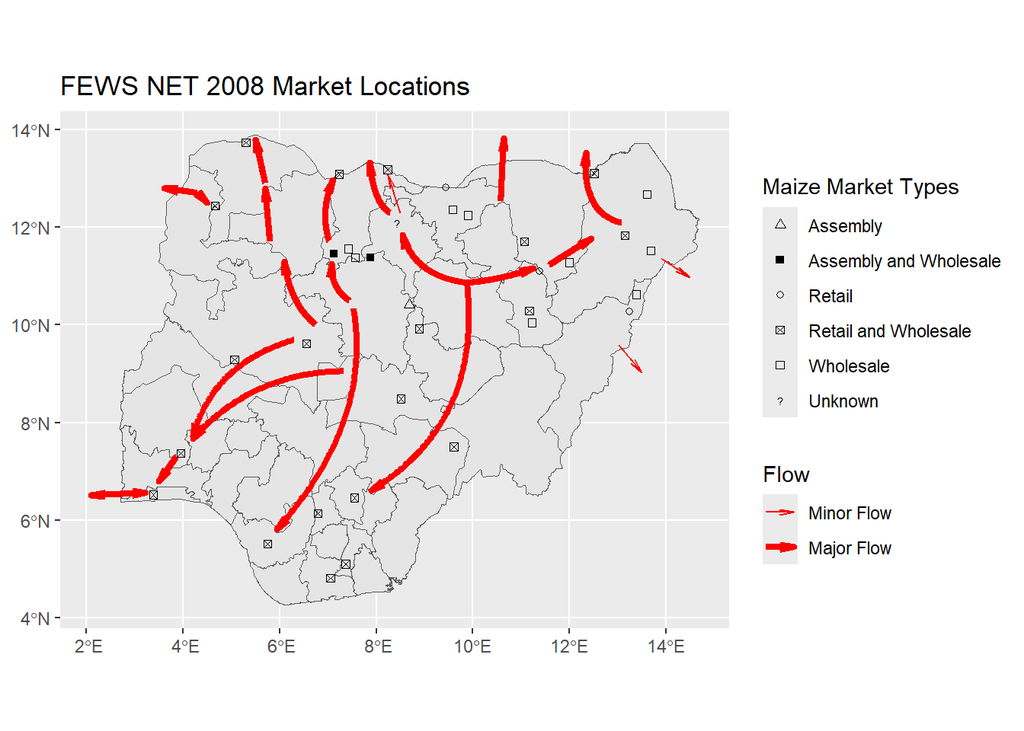

Figure 9: FEWS NET 2008 Maize Markets

```r
Maize = c("A", "A_R_W", "A_W", "R", "R_W", "W", "?")
m_shape  = c(2, 11, 15, 1, 7, 0, 63)
m_label  = c("Assembly", "Assembly, Retail and Wholesale", "Assembly and Wholesale", "Retail", "Retail and Wholesale", "Wholesale", "Unknown")


df_markets_shapes <- data.frame(Maize = Maize, m_shape = m_shape, m_label = m_label)

vect_markets_shapes <- tidyterra::left_join(vect_markets_geo, df_markets_shapes, by = c("Maize") )

vect_smooth_flows_maize$flow <- factor(vect_smooth_flows_maize$flow, labels = c("Minor Flow", "Major Flow"))


linewidth_map <- c(
  "Minor Flow" = 0.5,
  "Major Flow" = 1.5 )


ggplot(vect_state_geo) +
  geom_spatvector() +
  geom_spatvector(
    data = vect_smooth_flows_maize, aes(linewidth = flow),
    colour = "red",
    arrow = arrow(angle = 10, length = unit(0.25, "cm"),type = "open")
  ) +
  scale_linewidth_manual(
    name = "Flow",  # Legend title
    values = linewidth_map  # Map factor levels to linewidths
  ) +
  geom_spatvector(
    data = vect_markets_shapes,
    aes(shape = Maize)
  ) +
  scale_shape_manual(
    values = setNames(
      df_markets_shapes$m_shape,
      df_markets_shapes$Maize)
    ,
    breaks = df_markets_shapes$Maize,
    labels = df_markets_shapes$m_label
  ) +
  labs(title = "FEWS NET 2008 Market Locations", shape = "Maize Market Types") +
  theme(
    plot.title = element_markdown(),
    axis.title = element_blank()
  )
```

# Millet Markets

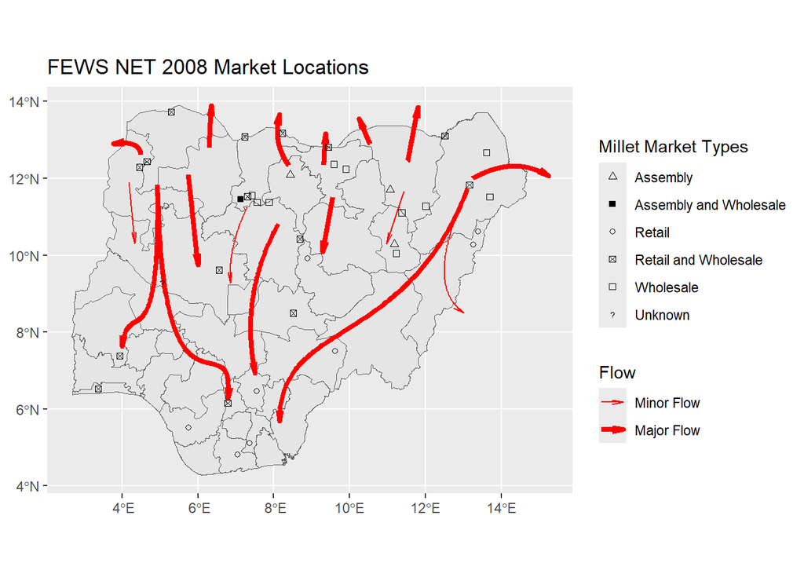

Figure 10: FEWS NET 2008 Millet Markets

```r
Millet = c("A", "A_R_W", "A_W", "R", "R_W", "W", "?")
m_shape  = c(2, 11, 15, 1, 7, 0, 63)
m_label  = c("Assembly", "Assembly, Retail and Wholesale", "Assembly and Wholesale", "Retail", "Retail and Wholesale", "Wholesale", "Unknown")


df_markets_shapes <- data.frame(Millet = Millet, m_shape = m_shape, m_label = m_label)

vect_markets_shapes <- tidyterra::left_join(vect_markets_geo, df_markets_shapes, by = c("Millet") )

vect_smooth_flows_millet$flow <- factor(vect_smooth_flows_millet$flow, labels = c("Minor Flow", "Major Flow"))


linewidth_map <- c(
  "Minor Flow" = 0.5,
  "Major Flow" = 1.5 )


ggplot(vect_state_geo) +
  geom_spatvector() +
  geom_spatvector(
    data = vect_smooth_flows_millet, aes(linewidth = flow),
    colour = "red",
    arrow = arrow(angle = 10, length = unit(0.25, "cm"),type = "open")
  ) +
  scale_linewidth_manual(
    name = "Flow",  # Legend title
    values = linewidth_map  # Map factor levels to linewidths
  ) +
  geom_spatvector(
    data = vect_markets_shapes,
    aes(shape = Millet)
  ) +
  scale_shape_manual(
    values = setNames(
      df_markets_shapes$m_shape,
      df_markets_shapes$Millet)
    ,
    breaks = df_markets_shapes$Millet,
    labels = df_markets_shapes$m_label
  ) +
  labs(title = "FEWS NET 2008 Market Locations", shape = "Millet Market Types") +
  theme(
    plot.title = element_markdown(),
    axis.title = element_blank()
  )
```

# Sorghum Markets

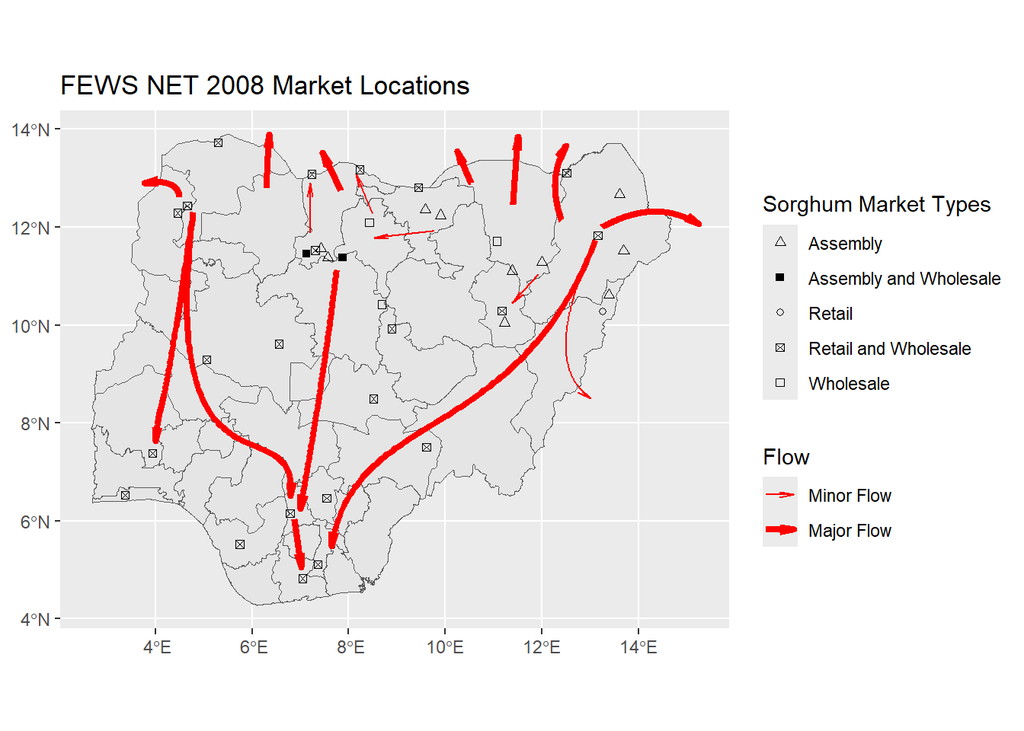

Figure 11: FEWS NET 2008 Sorghum Markets

```r
Sorghum = c("A", "A_R_W", "A_W", "R", "R_W", "W", "?")
m_shape  = c(2, 11, 15, 1, 7, 0, 63)
m_label  = c("Assembly", "Assembly, Retail and Wholesale", "Assembly and Wholesale", "Retail", "Retail and Wholesale", "Wholesale", "Unknown")


df_markets_shapes <- data.frame(Sorghum = Sorghum, m_shape = m_shape, m_label = m_label)

vect_markets_shapes <- tidyterra::left_join(vect_markets_geo, df_markets_shapes, by = c("Sorghum") )

vect_smooth_flows_sorghum$flow <- factor(vect_smooth_flows_sorghum$flow, labels = c("Minor Flow", "Major Flow"))


linewidth_map <- c(
  "Minor Flow" = 0.5,
  "Major Flow" = 1.5 )


ggplot(vect_state_geo) +
  geom_spatvector() +
  geom_spatvector(
    data = vect_smooth_flows_sorghum, aes(linewidth = flow),
    colour = "red",
    arrow = arrow(angle = 10, length = unit(0.25, "cm"),type = "open")
  ) +
  scale_linewidth_manual(
    name = "Flow",  # Legend title
    values = linewidth_map  # Map factor levels to linewidths
  ) +
  geom_spatvector(
    data = vect_markets_shapes,
    aes(shape = Sorghum)
  ) +
  scale_shape_manual(
    values = setNames(
      df_markets_shapes$m_shape,
      df_markets_shapes$Sorghum)
    ,
    breaks = df_markets_shapes$Sorghum,
    labels = df_markets_shapes$m_label
  ) +
  labs(title = "FEWS NET 2008 Market Locations", shape = "Sorghum Market Types") +
  theme(
    plot.title = element_markdown(),
    axis.title = element_blank()
  )
```

# Conclusions

The 2008 FEWS NET markets and market flows are now quite old, but there are very few other sources that combine all of the market information in one source (cf. Ospina Patino and Chuma 2015). Given that the market flow maps will be mainly used for illustrative purposes they are still useful, and provide an incentive to update the maps by other organisations.

The flow maps need to be linked or compared to the consumption and production maps in order to complete the narrative.

## References

FEWS NET. 2008a. *Production and Trade Flow Map: Cassava, Nigeria, Normal Year*.

FEWS NET. 2008b. *Production and Trade Flow Map: Cowpea, Nigeria, Normal Year*.

FEWS NET. 2008c. *Production and Trade Flow Map: Maize, Nigeria, Normal Year*.

FEWS NET. 2008d. *Production and Trade Flow Map: Millet, Nigeria, Normal Year*.

FEWS NET. 2008e. *Production and Trade Flow Map: Sorghum, Nigeria, Normal Year*.

FEWS NET. 2009. *Markets and Trade Glossary*. USAID.

Herrington, C., J. Funes, K. Lividini, et al. 2018. “Subnational Prioritization for Biofortification Interventions in Nigeria.” *30th International Conference of Agricultural Economists* (Vancouver, British Columbia, Canada), July. https://doi.org/10.22004/AG.ECON.277092.

Ospina Patino, Marco Tulio, and Ezedinma Chuma. 2015. “Understanding the Linkage of Urban and Rural Markets of Cassava Products in Nigeria.” *African Journal of Agricultural Research* 10 (40): 3804–13. https://doi.org/10.5897/ajar12.1037.